# A Survival Model in Stan

Eren M. Elçi

2018-11-15

The goal of this short case study is two-fold. Firstly, I wish to demonstrate essentials of a Bayesian workflow using the probabilistic programming language Stan. Secondly the analysis shows that doing posterior (and prior) predictive checks for (right) censored (survival) data requires an adjustment of the standard method utilized for drawing samples from the posterior preditive distribution.

The dataset we consider here is known as the mastectomy dataset. As the title already suggest, we will implement the simplest, and probably most commonly used survival model, also sometimes known as (Cox’s) proportional hazard model.

This case study is motivated by Austin Rochford’s related PyMC3 [blog post](https://austinrochford.com/posts/2015-10-05-bayes-survival.html). See also [this](https://docs.pymc.io/notebooks/bayes_param_survival_pymc3.html) updated version, now part of the official PyMC3 documentation. The same dataset was also studied by the same author in [this](https://docs.pymc.io/notebooks/survival_analysis.html) related case study.

The beauty or advantage of the Bayesian framework is that we can avoid any technicality or approximation due to what is known as *ties* in the dataset, usually encountered in real datasets and which need special treatments/considerations in the frequentist Cox Proportional Hazard framework (see e.g. `coxph`). This is because we model the baseline hazard explicitly and hence do not need to revert to what is known as a pseudo-likelihood.

For a good and concise description of the frequentist approach and the utilized pseudo-likelihood, see chapter 9.4 and the related appendix in [Computer Age Statistical Inference](https://web.stanford.edu/~hastie/CASI/index.html) by Efron and Hastie.

Moreover, the Bayesian framework allows us to easily scrutinize our model(s) beyond what is apparently possible with standard frequentist approaches, hence allowing us to quickly identify aspects of the true/observed dataset that are not well described by our model(s). This allows us to systematically and iteratively probe the applicability and limits of our model(s).

Before we dive into the matter, I would like to thank Tiago Cabaço and Jacob de Zoete for valuable feedback on an early draft of this case study. I also would like to thank Aki Vehtari, Arya Pourzanjani and Jacki Novik for fruitful discussions on survival models, which will find applications beyond this case study… Stay tuned.

Now, let’s first have a look at the data:

A mastectomy dataset

| time | event | metastized |
| --- | --- | --- |
| 23 | TRUE | 0 |
| 47 | TRUE | 0 |
| 69 | TRUE | 0 |
| 70 | FALSE | 0 |
| 100 | FALSE | 0 |
| 101 | FALSE | 0 |
| 148 | TRUE | 0 |
| 181 | TRUE | 0 |
| 198 | FALSE | 0 |
| 208 | FALSE | 0 |

More precisely, each row in the dataset represents observations from a woman diagnosed with breast cancer that underwent a mastectomy.

- The column `time` represents the time (in months) post-surgery that the woman was observed.
- The column `event` indicates whether or not the woman died during the observation period.
- The column `metastized` represents whether the cancer had metastized prior to surgery.

  The cancers are classified as having metastized or not based on a histochemical marker.

Next, let’s look at some characteristics of the data to get a bigger picture of the problem.

## Proportion of censored patients

It is always a good to start to study the extent of censoring, below we do this for the two subpopulations corresponding to `metastized=FALSE` and `metastized=TRUE`, respectively.

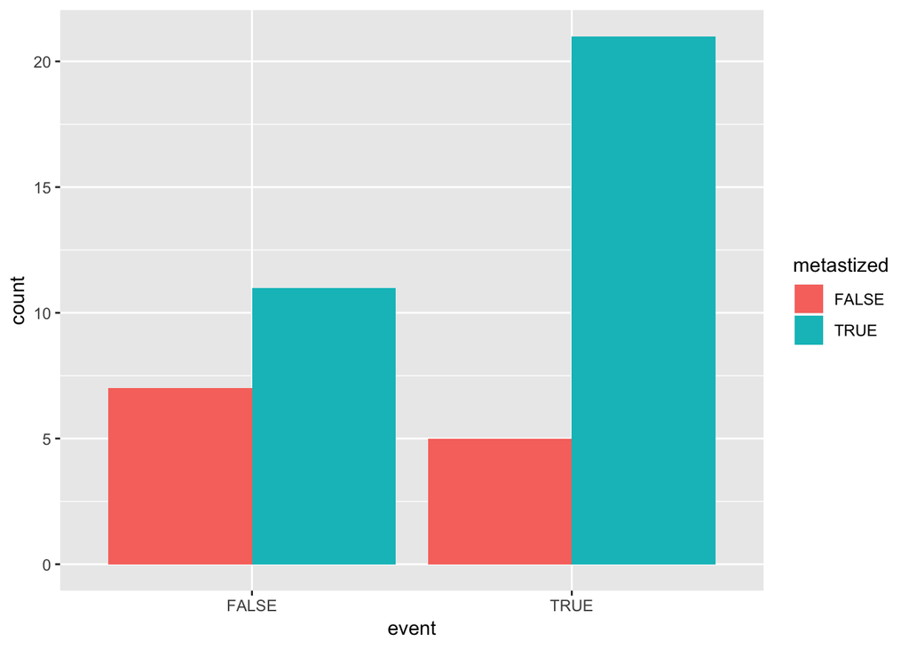

## (Censored) Event times

Let’s inspect some of the “global” characteristics of the event time distribution, stratified w.r.t. censoring, i.e. `event`, and metastization, i.e. `metastized`.

Stratified quantitative characteristics of event times

| event | metastized | mean_time | median_time | sd_time |
| --- | --- | --- | --- | --- |
| FALSE | FALSE | 159.0000 | 198 | 65.47519 |
| FALSE | TRUE | 151.0909 | 145 | 52.67344 |
| TRUE | FALSE | 93.6000 | 69 | 67.74806 |
| TRUE | TRUE | 48.0000 | 40 | 37.75315 |

### Histograms

Below we show histograms for each, the event times as well as the censored survival times. The dotted vertical lines show the corresponding means.

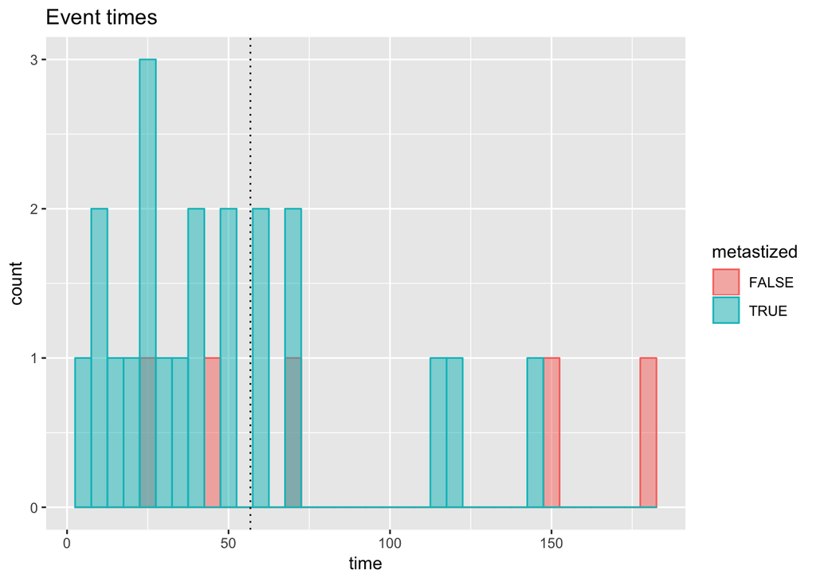

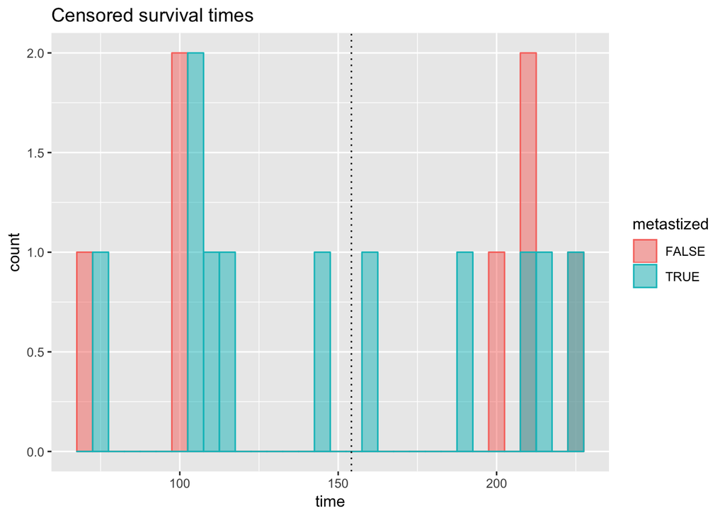

# Some math (some notation)

Central to survival models is the survival function $S(t)$ defined as

$$S(t) = \mathbb{P}[T>t] = e^{-H(t)}$$
Here $T$ is a the survival time of an individual and thus $T>t$ denotes the event that the patient or individual survived beyond time $t$. $H(t)$ is known as the cumulative hazard and can be shown to be given by

$$H(t) = \int_{0}^{t}{\rm d}u~h(u)$$

Here we introduced the hazard rate $h(t)$

We discard the dependence on latent parameters such as $\mathbf{\beta}$ or $\gamma$ below, for the sake of readability.

$$h(t;\mathbf{x}) = h_0(t) e^{\mathbf{x}'\cdot\boldsymbol{\beta}}$$

Here $\mathbf{x}$ is a vector of covariates describing an individual. The above makes it apparent why such models are often referred to as *proportional* hazard models. Further, we make the assumption that the baseline hazard $h_0$ fulfills

In our mastectomy dataset it is simply a scalar indicator corresponding to the column `metastized` above.

$$h_0(t) = h_0.$$

Our Bayesian analysis therefore has the unknown parameters $\boldsymbol{\beta}$ and $h_0$ where we parametrize the latter as $h_0 = e^\gamma$. Note that the above implies (or is equivalent to) $T$ having an exponential law with rate parameter equal to $\exp{(\mathbf{x}'\cdot \boldsymbol{\beta}+ \gamma)}$.

For the keen reader, try to verify (or convince yourself) that one has in the limit $dt\rightarrow 0$

$$h(t)dt \doteq \mathbb{P}\left[T\in (t,t+dt) \vert T\geq t\right]$$

To come back to our dataset above, we are going use the indicator `metastized` as the only covariate in $\mathbf{x}$ per individual, essentially giving us two baseline hazards for the two sub-populations. More precisely women without metastization prior to surgery are characterised by a (constant) baseline hazard equal to $\lambda_0=e^{\gamma}$ and women with metastization prior to surgery are characterised by a (constant) baseline hazard equal to $e^{\gamma + \beta}$, which, depending on the sign of $\beta$, might be larger or smaller than $\lambda_0$.

# Stan

Now let’s get our hands dirty (or actually our keyboard) and start specifying our corresponding generative model in Stan!

## Data block

Here we define precisely the type and dimensions of data provided externally to Stan.

E.g. via rstan, pystan or cmdstan.

```stan
data {
    int<lower=1> N_uncensored;
    int<lower=1> N_censored;
    int<lower=0> NC;
    matrix[N_censored,NC] X_censored;
    matrix[N_uncensored,NC] X_uncensored;
    vector<lower=0>[N_censored] times_censored;
    vector<lower=0>[N_uncensored] times_uncensored;
}
```

`N_uncensored` and `N_censored` are the number of women for which `event=1` and `event=0`, respectively. In survival model terminology, the former are uncensored instances, for which death (the event or endpoint of interest) was observed, and the latter are censored instances, for which no event was observed in the observation time `time`. The variable `N_C` is the number of covariates, in our case equal to $1$, since we only use `metastized`. Note that we allow for `N_C` to be $0$, which corresponds to the case where we fit one baseline hazard to the entire population.

For the sake of performance we split the actual design matrix into two, corresponding to `event=1` and `event=0`. `X_uncensored` and `X_censored` in our particular case will be matrices with only one column, each.

That is to be able to use vectorized statements, see below

Lastly, `times_censored` and `times_uncensored` contain the values of `time` in the dataframe `df`, separated according to `event=0` and `event=1`, respectively.

## Parameters block

Here we define all parameters that we wish to infer.

```stan
parameters {
    vector[NC] betas;
    real intercept;
}
```

Note that `betas` corresponds to $\boldsymbol{\beta}$ and `intercept` to $\gamma$.

## Model block

Here we define the likelihood and priors. Before we do so, I’d like to quote [Jonah Gabry](http://iserp.columbia.edu/people/jonah-gabry):

> “Choosing priors is about including information while allowing the chance of being wrong.”

In this sense, let’s hack the model block:

```stan
model {
    betas ~ normal(0,2);
    intercept ~ normal(-5,2);
    target += exponential_lpdf(times_uncensored | exp(intercept+X_uncensored*betas));
    target += exponential_lccdf(times_censored | exp(intercept+X_censored*betas));
}
```

To get an intuition for the prior choice of `intercept` or actually $\gamma$, observe that $e^{-\gamma}$ is equal to the mean of baseline exponential (which in the data is around $100$, hence $\gamma\approx -4.6$).

Note that implicit here is the assumption that survival times are mutually independent.

Moreover, above we use *vectorized* statements, which makes the computation more efficient than using, say, a for loop and iterating over all individuals. This is the main reason why we decided to work with the `_censored` and `_uncensored` suffixes and split the data, as opposed to the variant where one keeps the data together and provides an boolean array/vector specifying which patients have a (right-) censored survival time.

## Generated Quantities Block

For the posterior predictive checks we will conduct below, that allow us to scrutinize aspects of our posterior induced family of survival models, we need to be able to sample survival times, for each individual (or a suitable subset of them), at a set of representative posterior induced model instances. These survival times are stored below in the vector `times_uncensored_sampled`. Note that we only generate survival times for individuals for which we actually observed an event.

Here we adopt the viewpoint that Bayesian statistics leads to families of models, each model weighted approximately proportional to the corresponding posterior probability of it.

```
generated quantities {
    vector[N_uncensored] times_uncensored_sampled;
    for(i in 1:N_uncensored) {
        times_uncensored_sampled[i] = exponential_rng(exp(intercept+X_uncensored[i,]*betas));
    }
}
```

A great improvement in Stan $2.18$ is the support of vectorized `_rng` statements, i.e. the possibility to draw vectors of random samples, instead of generating them on scalar based within a for-loop.

## Model compilation

```r
library(rstan)
rstan_options(auto_write = TRUE)
sm <- stan_model("~/Desktop/Stan/A_Survival_Model_in_Stan/exponential_survival_simple_ppc.stan")
```

# Data preparation

```r
N <- nrow(df)
X <- as.matrix(pull(df, metastized))
is_censored <- pull(df,event)==0
times <- pull(df,time)
msk_censored <- is_censored == 1
N_censored <- sum(msk_censored)
```

Combine (couple) all the data into one named list with reference names corresponding precisely to the actual names as defined in the data block of our Stan model.

```r
stan_data <- list(N_uncensored=N-N_censored,
                  N_censored=N_censored,
                  X_censored=as.matrix(X[msk_censored,]),
                  X_uncensored=as.matrix(X[!msk_censored,]),
                  times_censored=times[msk_censored],
                  times_uncensored = times[!msk_censored],
                  NC=ncol(X)
)
```

# Fitting the model

```r
fit <- sampling(sm, data=stan_data, seed=42, chains=4, cores=2, iter=4000)
```

# Inspecting results

Consider especially the `ess` and `rhat` columns below, which correspond to the effective sample size and the potential scale reduction statistics. In a nutshell, `rhat` should be very close to $1$ which indicates that the chain(s) mixed (converged) and `ess` should be as close as possible to the total number of MCMC iterations, excluding warmup (excluding burn-in).

Starting in Stan 2.18 `ess` can in fact be larger than the number of MCMC iterations, essentially due to what is known as anti-correlations (yes NUTS and HMC can sometimes be unbelievable super-efficient!). For more details on the two quantities see the section [General MCMC diagnostics](http://mc-stan.org/bayesplot/articles/visual-mcmc-diagnostics.html#general-mcmc-diagnostics) in the bayesplot vignette [Visual MCMC diagnostics using the bayesplot package](http://mc-stan.org/bayesplot/articles/visual-mcmc-diagnostics.html). For a detailed example regarding the updates on `ess` and `rhat` in 2.18 I can highly recommend Aki Vehtari’s [Rank-normalized split-Rhat and relative efficiency estimates](https://avehtari.github.io/rhat_neff/rhat_neff.html)

Posterior summary

| term | estimate | std.error | conf.low | conf.high | rhat | ess |
| --- | --- | --- | --- | --- | --- | --- |
| intercept | -5.7456285 | 0.4259313 | -6.6556501 | -4.992377 | 1.001476 | 1669 |
| betas[1] | 0.8702448 | 0.4787253 | -0.0027207 | 1.858607 | 1.001180 | 1761 |

```
## 0 of 8000 iterations ended with a divergence.
```

```
## 0 of 8000 iterations saturated the maximum tree depth of 10.
```

## Visual inspection of the posterior

```r
library(bayesplot)
library(survival)
post <- as.array(fit)
fit_cox <- coxph(Surv(time, event)~metastized, data=df)
coef_cox <- coef(fit_cox)
se_cox <- sqrt(fit_cox$var)
```

### Kernel density plots of posterior draws with chains separated but overlaid on a single plot.

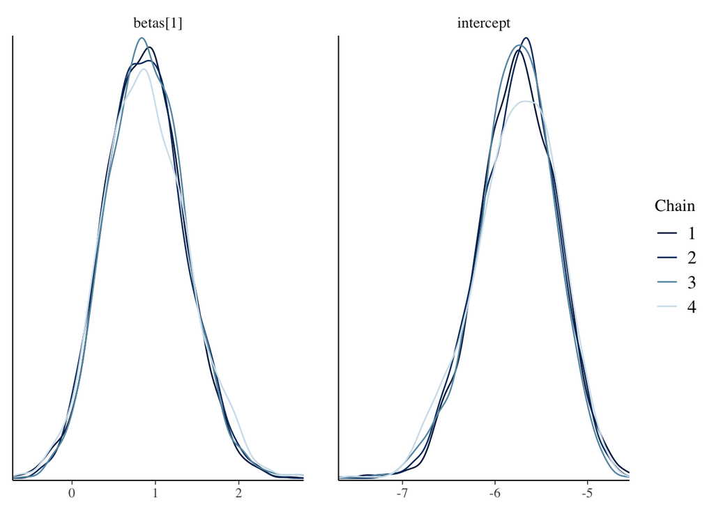

```r
mcmc_dens_overlay(post, pars=c("betas[1]", "intercept"))
```

### Plots of uncertainty intervals computed from posterior draws with all chains merged.

Using the `coxph` routine in the survival package, see the code of this RMarkdown.

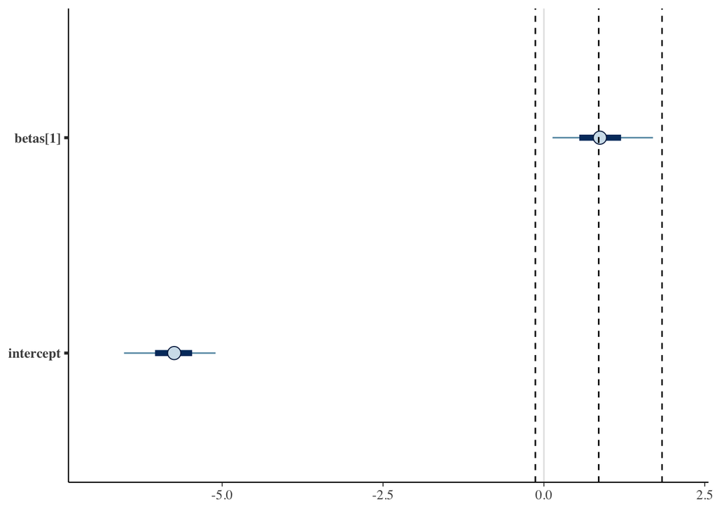

```r
mcmc_intervals(post, pars=c("betas[1]", "intercept")) +
  vline_at(c(coef_cox-1.96*se_cox, coef_cox, coef_cox+1.96*se_cox),linetype="dashed")
```

### Hazard

Let us also separately compare the 95% credible interval for the baseline (that is `metastized==0`) hazard with what one would obtain from an exact maximum likelihood calculation:

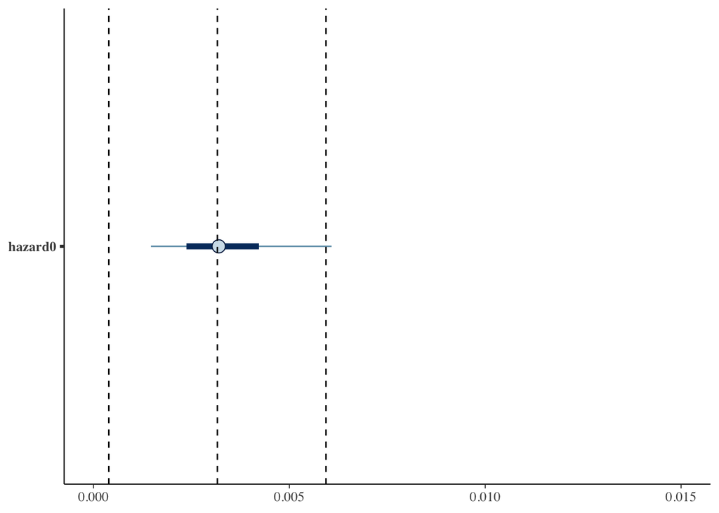

```r
df_0 <- filter(df, metastized==0)
df_1 <- filter(df_0, event==TRUE)
baseline_hazard_mle <- nrow(df_1)/sum(pull(df_0, "time"))
baseline_hazard_mle_sd <-  sqrt(nrow(df_1))/sum(pull(df_0, "time"))
df_fit <- as.tibble(as.data.frame(fit)) %>% mutate(hazard0=exp(intercept))
mcmc_intervals(df_fit, pars=c("hazard0")) +
  vline_at(c(baseline_hazard_mle-1.96*baseline_hazard_mle_sd, baseline_hazard_mle,baseline_hazard_mle+1.96*baseline_hazard_mle_sd),linetype="dashed")+
  xlim(0, .015)
```

and also for the `metastized==1` cases:

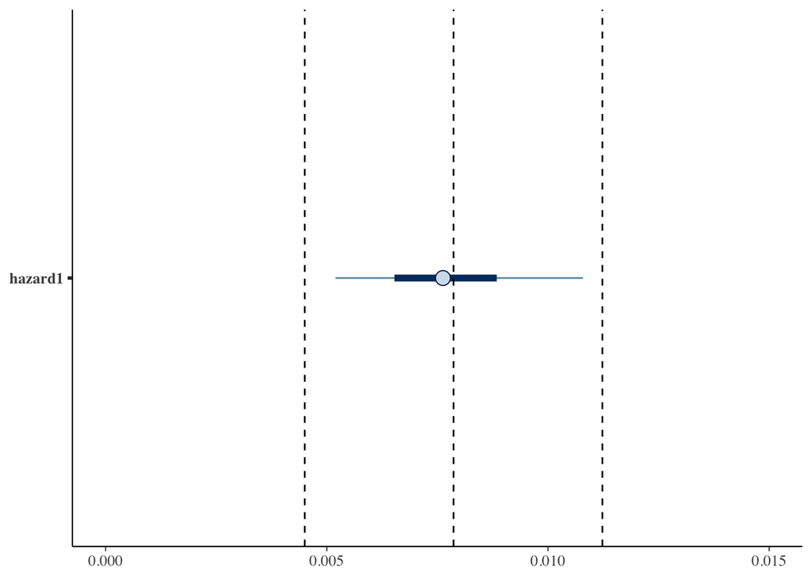

```r
df_0 <- filter(df, metastized==1)
df_1 <- filter(df_0, event==TRUE)
baseline_hazard_mle <- nrow(df_1)/sum(pull(df_0, "time"))
baseline_hazard_mle_sd <-  sqrt(nrow(df_1))/sum(pull(df_0, "time"))
df_fit <- df_fit %>% mutate(hazard1=exp(intercept+`betas[1]`))
mcmc_intervals(df_fit, pars=c("hazard1")) +
  vline_at(c(baseline_hazard_mle-1.96*baseline_hazard_mle_sd, baseline_hazard_mle,baseline_hazard_mle+1.96*baseline_hazard_mle_sd),linetype="dashed")+
  xlim(0, .015)
```

### Pairs plot

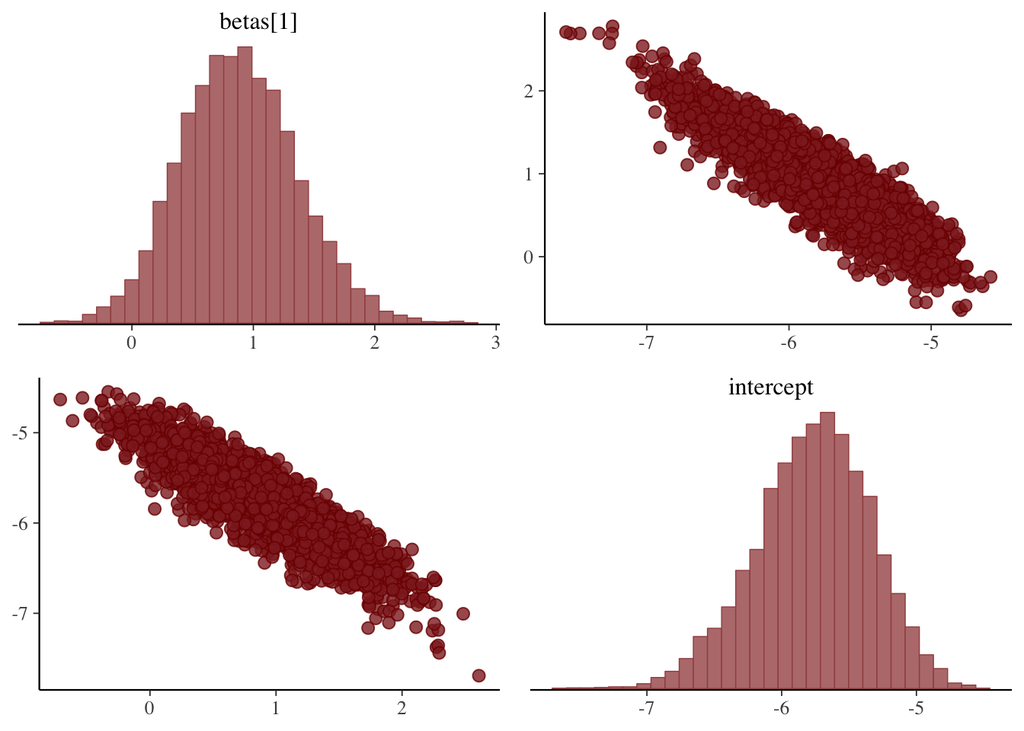

```r
color_scheme_set("red")
mcmc_pairs(post, pars=c("betas[1]", "intercept"))
```

### Hex plot

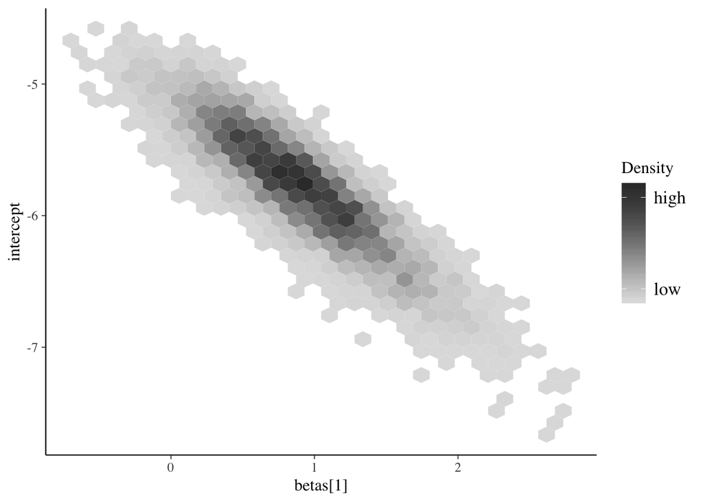

```r
color_scheme_set("gray")
mcmc_hex(post, pars=c("betas[1]", "intercept"))
```

### Trace plot

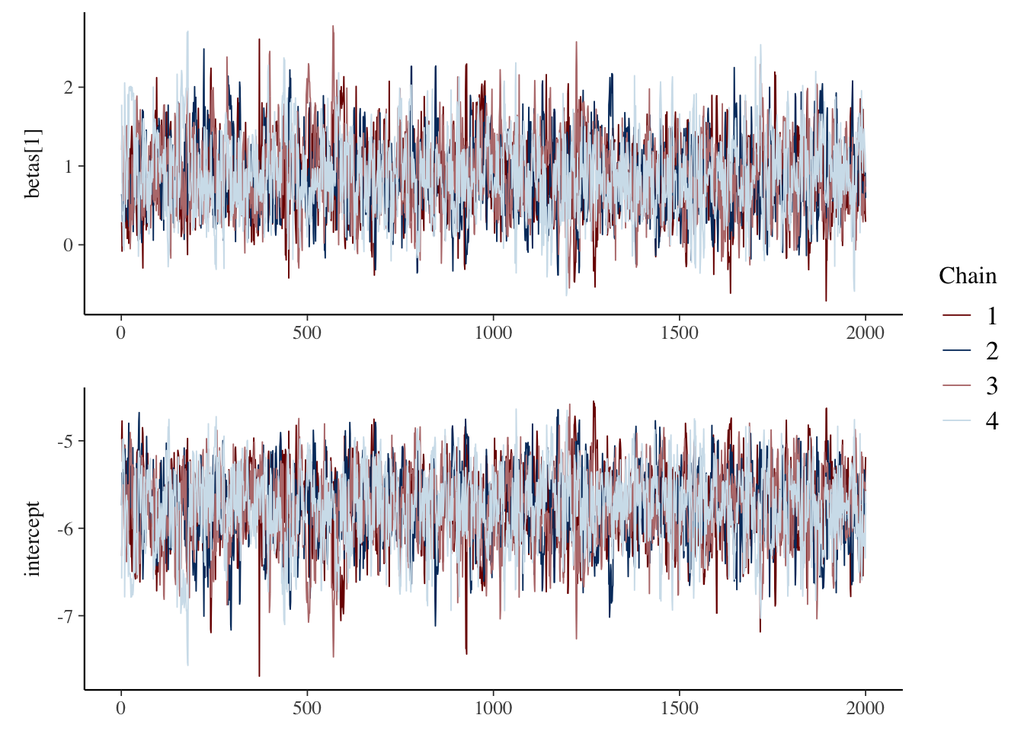

```r
color_scheme_set("mix-blue-red")
mcmc_trace(post, pars=c("betas[1]", "intercept"),
           facet_args = list(ncol = 1, strip.position = "left")
           )
```

# Survival curves

Below we show the survival curves that we estimated based on our model together with a $95\%$ credible intervals.

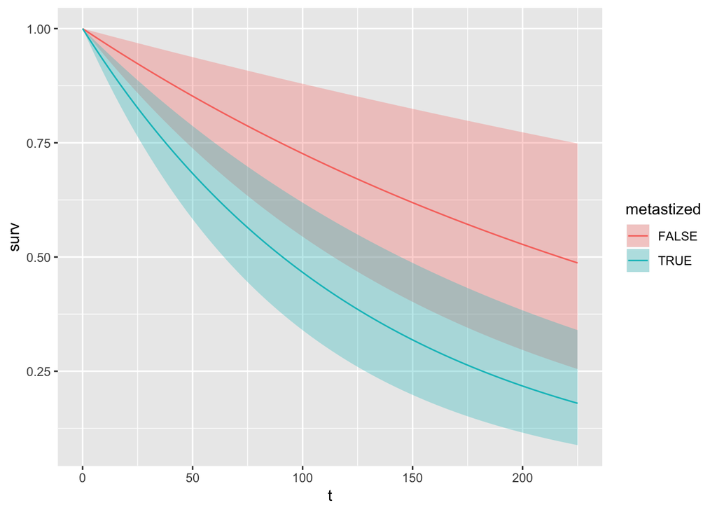

For reference below is the classical Kaplan-Meier estimate

Created with the R package `survminer`. For a concise derivation of the estimator see chapter 9.2 in Efron & Hastie Computer Age Statistical Inference (link above).

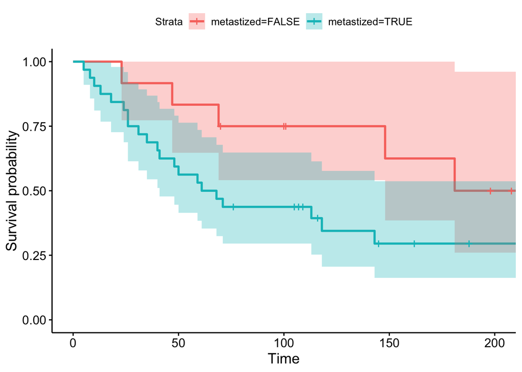

# Posterior predictive checks

Posterior predictive checks constitute a family of powerful methods to scrutinize relevant aspects of your model.

See the excellent bayesplot vignette [Graphical posterior predictive checks using the bayesplot package](https://cran.r-project.org/web/packages/bayesplot/vignettes/graphical-ppcs.html) for an introduction and practical instructions.

Below we run various posterior predictive checks constrained to the instances (individuals) that came with non-censored survival times:

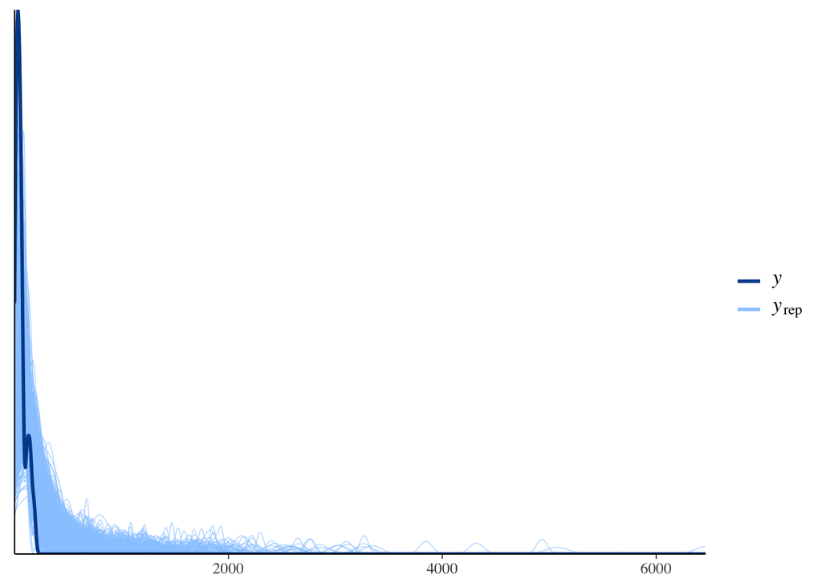

```r
surv_times_rep <- as.matrix(map_dfr(1:dim(post)[2], ~as.tibble(post[,.,sprintf("times_uncensored_sampled[%d]", 1:stan_data$N_uncensored)])))
surv_times_train <- times[!msk_censored]
###########################################################################################
color_scheme_set("brightblue")
ppc_dens_overlay(surv_times_train, surv_times_rep[1:1000,])
```

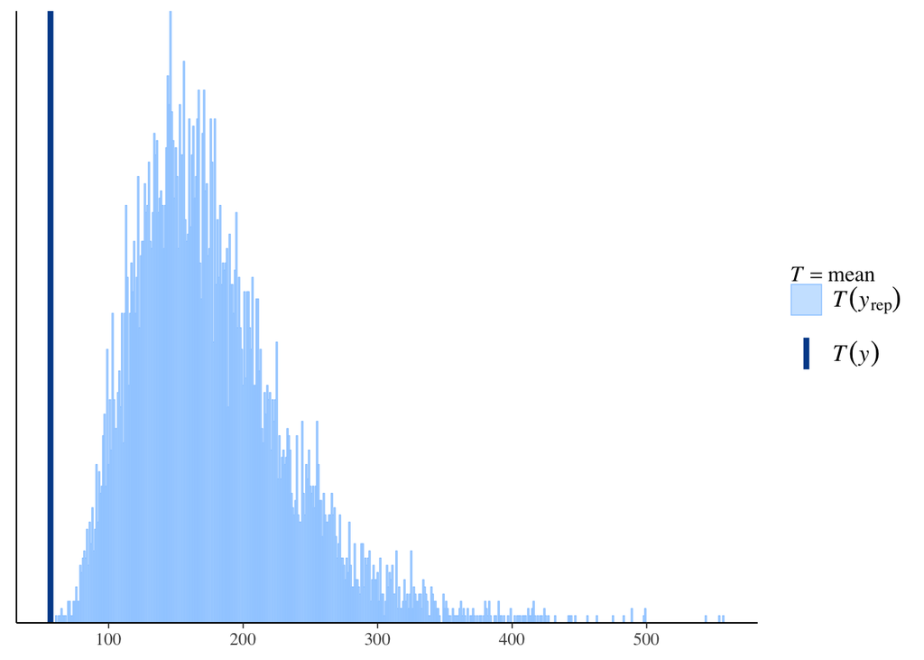

```r
ppc_stat(surv_times_train, surv_times_rep, binwidth = 1, stat = "mean")
```

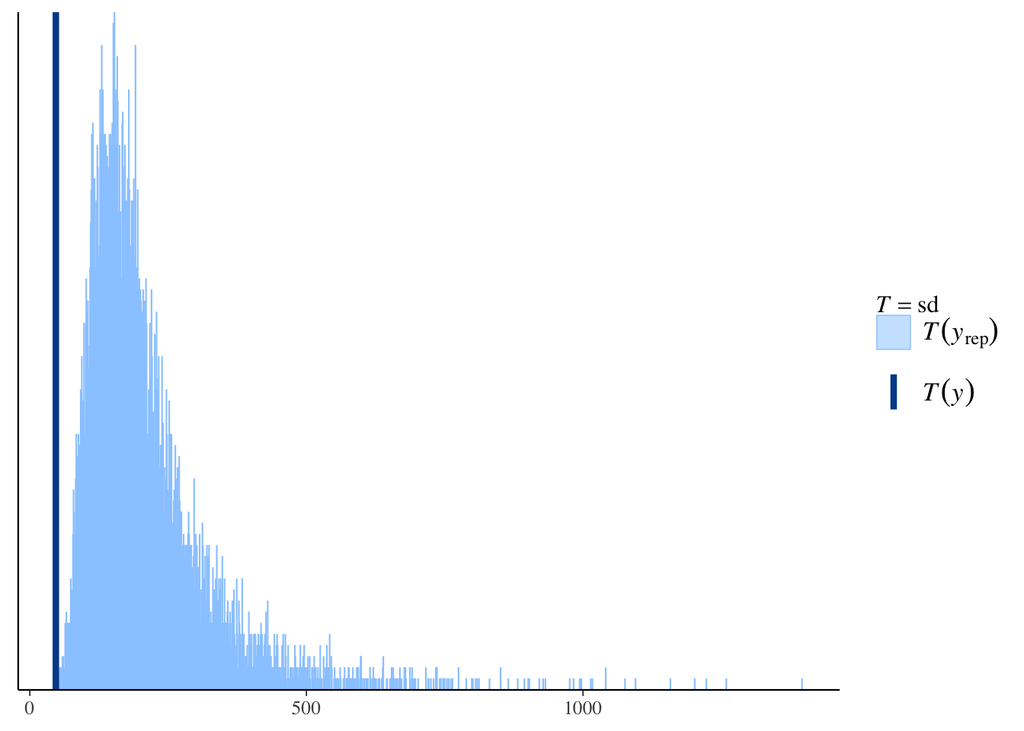

```r
ppc_stat(surv_times_train, surv_times_rep, binwidth = 1, stat = "sd")
```

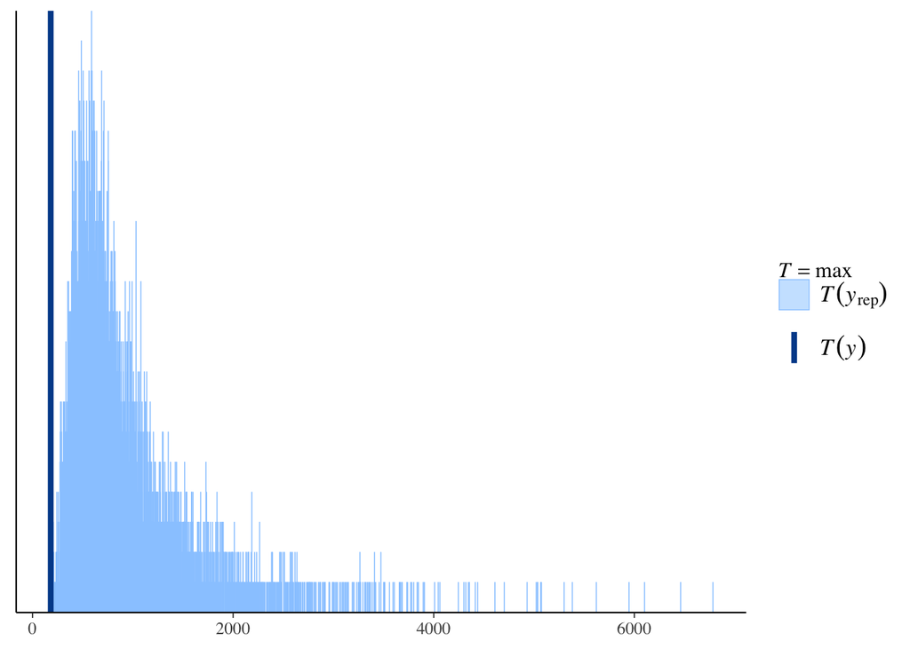

```r
ppc_stat(surv_times_train, surv_times_rep, binwidth = 1, stat = "max")
```

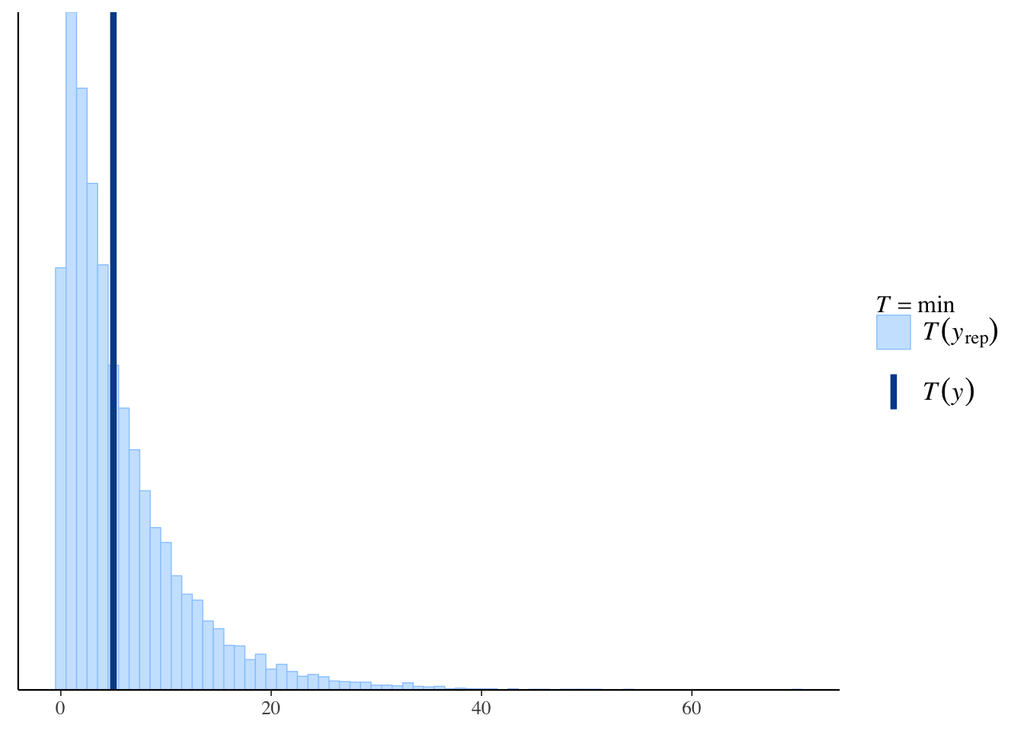

```r
ppc_stat(surv_times_train, surv_times_rep, binwidth = 1, stat = "min")
```

Our posterior predictive checks from above suggest that our model suffers from overdispersion and a tendency for too large survival times. Now would be the time to think about improving the current model, e.g. one could consider accelerated failure time models, semi-parametric base-line hazards or more general parametric survival models, like the Royston & Parmar-based family of models.

[Flexible parametric proportional-hazards and proportional-odds models for censored survival data, with application to prognostic modelling and estimation of treatment effects.](https://www.ncbi.nlm.nih.gov/pubmed/12210632)

However as it turns out we did overlook something crucial here:

> The samples we have observed for uncensored survival times are in fact all conditioned to be less equal the length of the study

One might call this also sampling from a truncated event time distribution, see [this](https://discourse.mc-stan.org/t/survival-models-in-rstanarm/3998/64?u=ermeel) comment on Stan discourse.

```stan
generated quantities {
    vector[N_uncensored] times_uncensored_sampled;
    {
        real tmp;
        real max_time;
        real max_time_censored;
        max_time = max(times_uncensored);
        max_time_censored = max(times_censored);
        if(max_time_censored > max_time) max_time = max_time_censored;

        for(i in 1:N_uncensored) {
            tmp= max_time + 1;
            while(tmp > max_time) {
                tmp = exponential_rng(exp(intercept+X_uncensored[i,]*betas));
            }
            times_uncensored_sampled[i] = tmp;
        }
    }

}
```

Note that we added additional brackets `{}` above, to change the variables `tmp, max_time, max_time_censored` to local variables so they are excluded from to the posterior output. We now compile the adjusted model, fit it and scrutinize the posterior predictive properties as above:

In technical terms, we created a local scope using the additional `{}`.

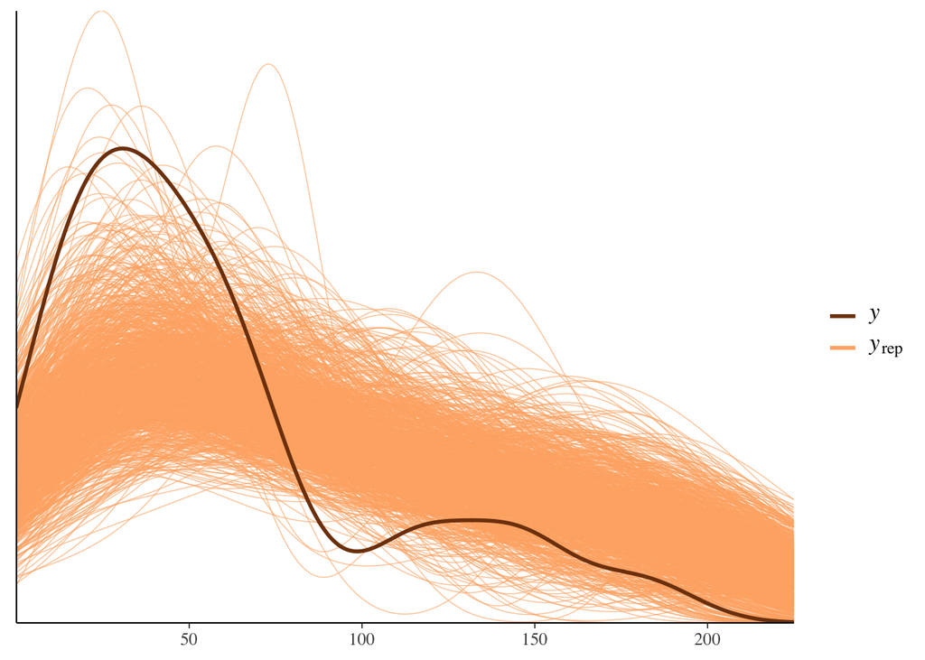

```r
sm2 <- stan_model("~/Desktop/Stan/A_Survival_Model_in_Stan/exponential_survival_simple_ppc_cond.stan")
fit2 <- sampling(sm2, data=stan_data, seed=42, chains=4, cores=2, iter=4000)
post2 <- as.array(fit2)
surv_times_rep2 <- as.matrix(map_dfr(1:dim(post2)[2], ~as.tibble(post2[,.,sprintf("times_uncensored_sampled[%d]", 1:stan_data$N_uncensored)])))
###########################################################################################
color_scheme_set("orange")
ppc_dens_overlay(surv_times_train, surv_times_rep2[1:1000,])
```

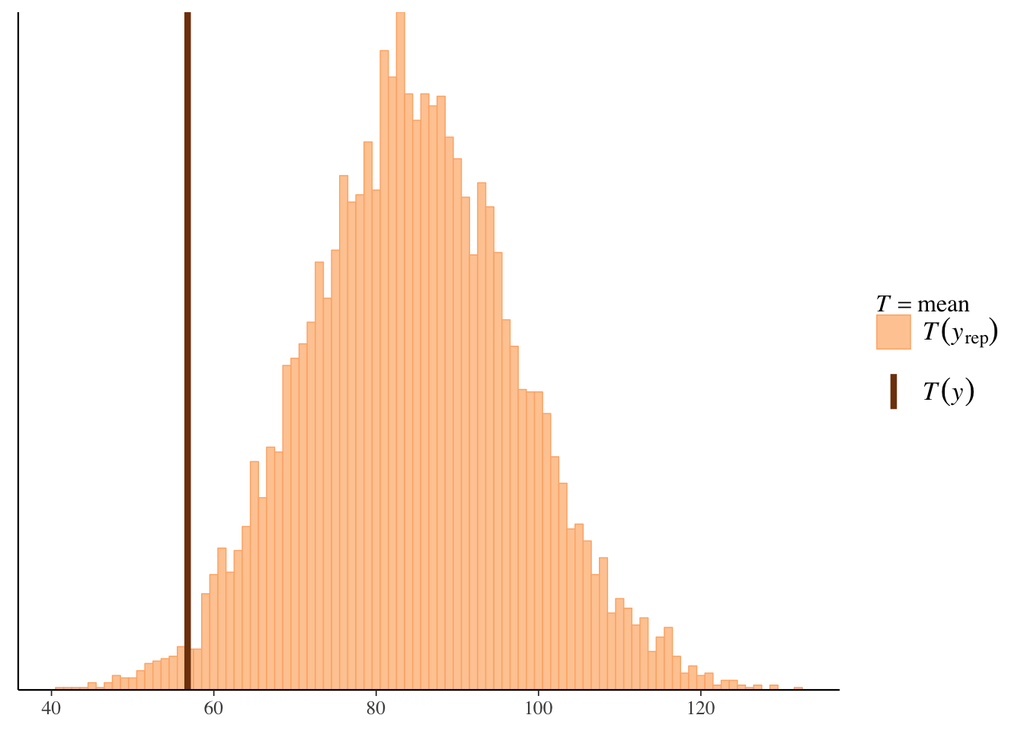

```r
ppc_stat(surv_times_train, surv_times_rep2, binwidth = 1, stat = "mean")
```

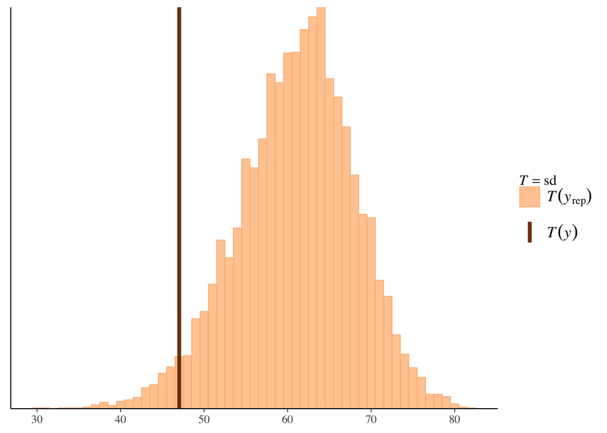

```r
ppc_stat(surv_times_train, surv_times_rep2, binwidth = 1, stat = "sd")
```

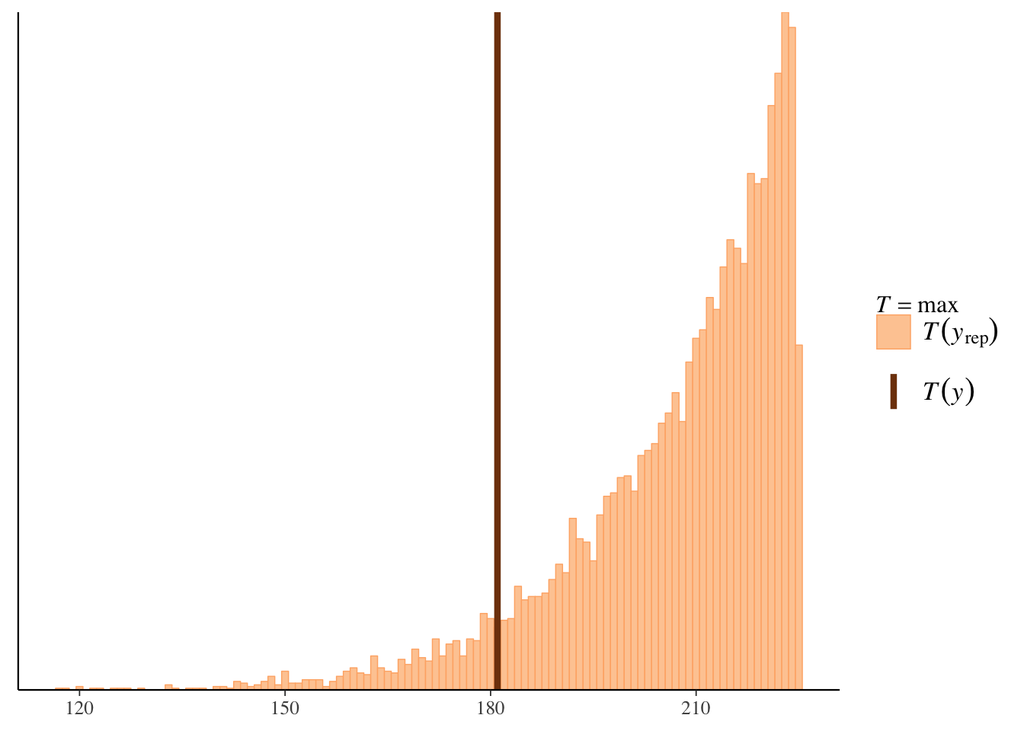

```r
ppc_stat(surv_times_train, surv_times_rep2, binwidth = 1, stat = "max")
```

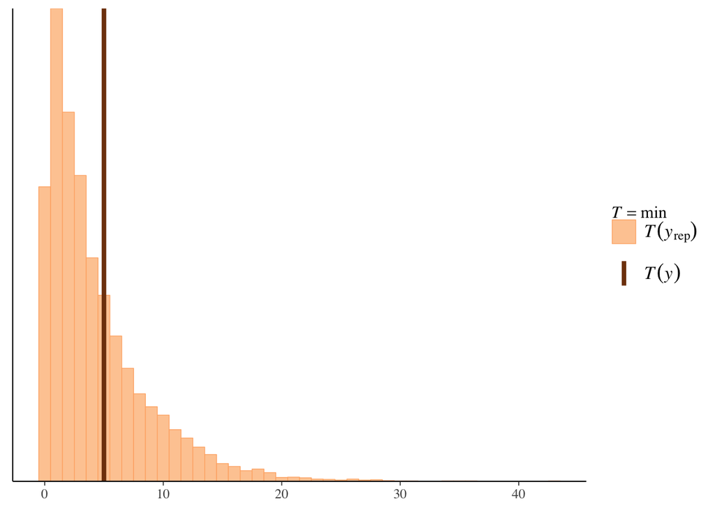

```r
ppc_stat(surv_times_train, surv_times_rep2, binwidth = 1, stat = "min")
```

As was pointed out in [this](https://discourse.mc-stan.org/t/survival-models-in-rstanarm/3998/66?u=ermeel) comment on Stan discourse by the user [lcomm](https://discourse.mc-stan.org/u/lcomm/summary), one can directly sample from an exponential distribution with upper bound using the following Stan function

This needs to be added to functions-block at the beginning of the Stan file.

```stan
real exponential_ub_rng(real beta, real ub) {
    real p = exponential_cdf(ub, beta);  // cdf for bounds
    real u = uniform_rng(0, p);
    return (-log1m(u) / beta);  // inverse cdf for value
  }
```

Our `generated quantities` block would then look as follows

```stan
generated quantities {
    vector[N_uncensored] times_uncensored_sampled;
    for(i in 1:N_uncensored) times_uncensored_sampled[i] = exponential_ub_rng(exp(intercept+X_uncensored[i,]*betas), max_time);
}
```

and we moved the calculation of `max_time` to the following `transformed data` block:

```stan
transformed data {
    real max_time;
    real max_time_censored;
    max_time = max(times_uncensored);
    max_time_censored = max(times_censored);
    if(max_time_censored > max_time) max_time = max_time_censored;
}
```